# Duplicate DHIS2 Indicators, Divergent Results

A Malaria RDT Test Positivity Rate Case Study from Nigeria

Published

May 30, 2026

> **Purpose:** Worked example for the DHIS2 Reporting Checklist — Domain 1 (Data Dictionary). Demonstrates why reporting the specific DHIS2 indicator UID, and verifying its formula against instance metadata, is essential. Data: Nigeria national HMIS (DHIS2), Kebbi State, 2020–2026.

## 1 Background

DHIS2 instances at national scale accumulate indicators over time as programmes, donors, and implementing partners add metrics without auditing what already exists. When two indicators carry similar names and appear to measure the same construct, analysts may select either one without realising the formulas differ. The problem is compounded by the fact that DHIS2 indicator names are assigned by the instance administrator and carry no enforced schema. A name that includes the acronym “TPR” does not guarantee the formula is correctly specified.

Nigeria’s national Health Management Information System (NHMIS), deployed on DHIS2, contains at least two pre-computed indicators that nominally measure RDT test positivity rate (TPR). Their formulas differ substantially. **Indicator B** (`uiA07P72s2Z`, named “Test Positivity Rate(TPR) (RDT)”) contains a formula error that adds the RDT positive count to the denominator. **Indicator A** (`l2eIpdluuTI`, named “% of Fever cases tested positive with RDT”) uses the default aggregation of each data element — the approach consistent with the intended formula. Indicator A is not without its own data quality concern: its denominator data element, “Persons presenting with fever & tested by RDT,” should capture only those who actually received an RDT, but if health workers record total fever attendees rather than exclusively tested patients, the denominator is inflated — deflating TPR below the true value.

This document:

1. Describes the two indicators and their exact data element and category option combo compositions, derived directly from DHIS2 instance metadata.
2. Shows the empirical divergence between the two indicators using state-level data from Kebbi State (January 2020 – April 2026), including a pre-transition period where the Indicator B would report ~100% TPR (not visible in available data because DHIS2 suppresses values exceeding 100%).
3. Documents that published studies and programme reports cite Nigeria DHIS2 TPR values without specifying which indicator was used.

## 2 Two DHIS2 indicators for RDT test positivity rate

Nigeria’s DHIS2 instance contains the following two indicators:

[output not shown]

**Category option combo (COC) UID reference:**

| COC UID | Age group | Scheme (category combination) |
| --- | --- | --- |
| `W50DgZrPrUk` | `<5yrs` | Old — Age(Malaria) |
| `ItGQGDRFD4t` | `>=5years` | Old — Age(Malaria) |
| `Bl7e1tsRGoZ` | `<5yrs` | New — NH19_Malaria Testing |
| `v0QZcUTuyjD` | `≥5yrs (excl PW)` | New — NH19_Malaria Testing |
| `V86mzY788hR` | `Preg Women (PW)` | New — NH19_Malaria Testing |

Indicator B’s name — “Test Positivity Rate(TPR) (RDT)” — contains the “TPR” acronym that programme staff and analysts routinely search for. Indicator A’s name uses different terminology (“fever cases tested positive”) and will not appear in a search for “TPR.” An analyst opening the Nigeria DHIS2 analytics interface and filtering indicators by “TPR” would find Indicator B first.

### 2.1a Denominator concern for Indicator A

Indicator A’s denominator data element, “Persons presenting with fever & tested by RDT” (`r6WOvUlcQm6`), is designed to count persons who both presented with fever **and** received an RDT — making it the intended denominator for HMIS-based TPR. However, if health workers record total fever attendees in this field regardless of whether they were tested (a documented data quality risk in high-workload facilities with incomplete RDT access), the denominator would exceed the actual number tested. Since persons not tested cannot be positive, the numerator remains unchanged while the denominator grows, deflating the reported TPR below the true positivity rate among those tested. This is distinct from Indicator B’s formula error, but the direction of bias is the same: both indicators can understate true TPR, through different mechanisms.

### 2.1 Data elements

Both indicators reference the same two data elements:

| Data Element | UID | Description |
| --- | --- | --- |
| Persons tested positive for malaria by RDT | `GEd2F6skCpT` | Numerator component |
| Persons presenting with fever & tested by RDT | `r6WOvUlcQm6` | Denominator component |

Both data elements belong to the category combination **NH19_Malaria Testing**, which in the current (post-2020) NHMIS form has three category option combos:

| Category | COC UID |
| --- | --- |
| `<5yrs` | `Bl7e1tsRGoZ` |
| `≥5yrs (excl PW)` | `v0QZcUTuyjD` |
| `Preg Women (PW)` | `V86mzY788hR` |

The same data elements also have a legacy **Age(Malaria)** category combination used before the form was revised:

| Category | COC UID |
| --- | --- |
| `<5yrs` | `W50DgZrPrUk` |
| `>=5years` | `ItGQGDRFD4t` |

### 2.2 Exact component-level formulas

**Indicator A — `l2eIpdluuTI`**

Uses the default category option combo (DHIS2 sums all disaggregated values server-side):

| Role | Data Element | DE UID | Category | COC UID |
| --- | --- | --- | --- | --- |
| Numerator | Persons tested positive for malaria by RDT | `GEd2F6skCpT` | *(default — all age groups summed)* | — |
| Denominator | Persons presenting with fever & tested by RDT | `r6WOvUlcQm6` | *(default — all age groups summed)* | — |

**Indicator B — `uiA07P72s2Z`**

Explicitly names category option combos, mixing old and new age-disaggregation schemes:

| Role | Data Element | DE UID | Category | COC UID | Scheme |
| --- | --- | --- | --- | --- | --- |
| Numerator | Persons tested positive for malaria by RDT | `GEd2F6skCpT` | `<5yrs` | `W50DgZrPrUk` | Old |
| Numerator | Persons tested positive for malaria by RDT | `GEd2F6skCpT` | `>=5years` | `ItGQGDRFD4t` | Old |
| Numerator | Persons tested positive for malaria by RDT | `GEd2F6skCpT` | `≥5yrs (excl PW)` | `v0QZcUTuyjD` | New |
| Numerator | Persons tested positive for malaria by RDT | `GEd2F6skCpT` | `Preg Women (PW)` | `V86mzY788hR` | New |
| Numerator | Persons tested positive for malaria by RDT | `GEd2F6skCpT` | `<5yrs` (new) | `Bl7e1tsRGoZ` | **missing from numerator** |
| **Denominator** ✗ | **Persons tested positive for malaria by RDT** | `GEd2F6skCpT` | *(default — all age groups)* | — | **ERROR: positives added to denominator** |
| Denominator | Persons presenting with fever & tested by RDT | `r6WOvUlcQm6` | `<5yrs` | `Bl7e1tsRGoZ` | New |
| Denominator | Persons presenting with fever & tested by RDT | `r6WOvUlcQm6` | `≥5yrs (excl PW)` | `v0QZcUTuyjD` | New |
| Denominator | Persons presenting with fever & tested by RDT | `r6WOvUlcQm6` | `Preg Women (PW)` | `V86mzY788hR` | New |
| Denominator | Persons presenting with fever & tested by RDT | `r6WOvUlcQm6` | `<5yrs` + `>=5years` (old) | — | **missing from denominator** |

Two errors compound:

**Pre-transition: falsely elevated TPR (suppressed by DHIS2).** Before Kebbi State facilities switched to the new `NH19_Malaria Testing` age-disaggregation scheme, new-scheme tested categories for `r6WOvUlcQm6` reported zero. Indicator B’s denominator therefore collapsed to `#{GEd2F6skCpT}` default (old-scheme positives) + 0. With the numerator approximating the same positives total, Indicator B would return TPR ≈ 100%. DHIS2 suppresses or does not return rows where a percentage indicator exceeds 100%, which is why Indicator B returns **zero rows for 2020–2021** in the Kebbi data — not because there was no malaria testing, but because the implicit value was implausibly high. The post-transition deflation (~26% from ~76%) and the pre-transition inflation (~100%) are two sides of the same formula errors.

## 3 Empirical comparison — Kebbi State, 2020–2026

```r
library(data.table)
library(tsibble)
library(ggplot2)
library(scales)

KEBBI_DIR <- "~/Library/Mobile Documents/com~apple~CloudDocs/Projects/MG2/reports/Nigeria/"
```

### 3.1 Facility-level TPR (MG2 method, independent of DHIS2 indicators)

```r
kebbi <- readRDS(file.path(KEBBI_DIR, "kebbi_cache.rds"))
setDT(kebbi)
cat("Kebbi rows:", format(nrow(kebbi), big.mark = ","),
    "| Date range:",
    format(min(as.Date(kebbi$Month)), "%Y-%m"), "to",
    format(max(as.Date(kebbi$Month)), "%Y-%m"), "\n")
```

```
#> Kebbi rows: 1,860,580 | Date range: 2020-01 to 2026-04
```

```r
# Age-disaggregation schemes
NUM_OLD <- "Persons tested positive for malaria by RDT_>=5years"
NUM_NEW <- c("Persons tested positive for malaria by RDT_≥5yrs (excl PW)",
             "Persons tested positive for malaria by RDT_Preg Women (PW)")
NUM_U5  <- "Persons tested positive for malaria by RDT_<5yrs"
DEN_OLD <- "Persons presenting with fever & tested by RDT_>=5years"
DEN_NEW <- c("Persons presenting with fever & tested by RDT_≥5yrs (excl PW)",
             "Persons presenting with fever & tested by RDT_Preg Women (PW)")
DEN_U5  <- "Persons presenting with fever & tested by RDT_<5yrs"
NUM_VALS <- c(NUM_U5, NUM_OLD, NUM_NEW)
DEN_VALS <- c(DEN_U5, DEN_OLD, DEN_NEW)

# Facility-level (leaves only)
rdt <- kebbi[effectiveLeaf == TRUE & data %in% c(NUM_VALS, DEN_VALS),
             .(orgUnit, Month, data, original)]
rdt[, component := fifelse(data %in% NUM_VALS, "numerator", "denominator")]

# Sum age groups per facility-month (na.rm = TRUE)
fac_sums <- rdt[, .(
  value = if (all(is.na(original))) NA_real_ else sum(original, na.rm = TRUE)
), by = .(orgUnit, Month, component)]

fac <- dcast(fac_sums, orgUnit + Month ~ component, value.var = "value")

# MG2 validity rules
fac[, num_adj := fifelse(
  is.na(numerator) & !is.na(denominator) & denominator > 0, 0, numerator
)]
fac[, valid := !is.na(num_adj) & !is.na(denominator) &
               denominator > 0 & num_adj <= denominator]

# Monthly aggregate
mg2_monthly <- fac[valid == TRUE, .(
  mg2_tpr = sum(num_adj) / sum(denominator) * 100,
  mg2_num = sum(num_adj),
  mg2_den = sum(denominator),
  n_fac   = .N
), by = Month]
mg2_monthly[, date := as.Date(Month)]
setorder(mg2_monthly, date)

cat("Monthly rows:", nrow(mg2_monthly), "\n")
```

```
#> Monthly rows: 76
```

### 3.2 DHIS2 indicators — state-level

```r
dhis2_cache <- readRDS(file.path(KEBBI_DIR, "kebbi_dhis2_indicators.rds"))
dhis2_correct <- as.data.table(dhis2_cache$correct)
dhis2_errored <- as.data.table(dhis2_cache$errored)

cat("Correct indicator rows:", nrow(dhis2_correct),
    "| Range:", format(min(dhis2_correct$date), "%Y-%m"), "to",
    format(max(dhis2_correct$date), "%Y-%m"), "\n")
```

```
#> Correct indicator rows: 76 | Range: 2020-01 to 2026-04
```

```r
cat("Erroneous indicator rows:", nrow(dhis2_errored),
    "| Range:", format(min(dhis2_errored$date), "%Y-%m"), "to",
    format(max(dhis2_errored$date), "%Y-%m"), "\n")
```

```
#> Erroneous indicator rows: 16 | Range: 2022-01 to 2026-04
```

```r
# Side-by-side comparison for months where both DHIS2 indicators are present
overlap <- merge(
  dhis2_correct[, .(date, correct_tpr = value, correct_num = numerator, correct_den = denominator)],
  dhis2_errored[, .(date, errored_tpr = value, errored_num = numerator, errored_den = denominator)],
  by = "date"
)
overlap[, tpr_gap_pp := round(correct_tpr - errored_tpr, 1)]
overlap[, den_ratio   := round(errored_den / correct_den, 2)]

overlap[, .(date,
            correct_tpr = round(correct_tpr, 1),
            errored_tpr = round(errored_tpr, 1),
            tpr_gap_pp,
            correct_den = format(correct_den, big.mark = ","),
            errored_den = format(errored_den, big.mark = ","),
            den_ratio)]
```

| date | correct_tpr | errored_tpr | tpr_gap_pp | correct_den | errored_den | den_ratio |
| --- | --- | --- | --- | --- | --- | --- |
| 2022-01-01 | 76.4 | 26.5 | 49.9 | 80,654 | 142,283 | 1.76 |
| 2022-02-01 | 77.4 | 26.8 | 50.6 | 79,858 | 141,647 | 1.77 |
| 2022-03-01 | 74.7 | 25.7 | 49.0 | 77,465 | 135,346 | 1.75 |
| 2022-04-01 | 74.2 | 25.4 | 48.8 | 73,484 | 127,999 | 1.74 |
| 2022-05-01 | 73.6 | 25.8 | 47.9 | 73,049 | 126,834 | 1.74 |
| 2022-06-01 | 74.3 | 25.6 | 48.8 | 79,970 | 139,421 | 1.74 |
| 2022-07-01 | 76.2 | 26.8 | 49.4 | 91,452 | 161,095 | 1.76 |
| 2022-08-01 | 79.0 | 28.7 | 50.4 | 124,321 | 222,598 | 1.79 |
| 2022-09-01 | 75.6 | 26.7 | 48.9 | 130,717 | 229,493 | 1.76 |
| 2022-10-01 | 82.0 | 30.0 | 52.0 | 113,474 | 206,505 | 1.82 |

[output cut: 6 more lines]

### 3.3 Three-way comparison plot

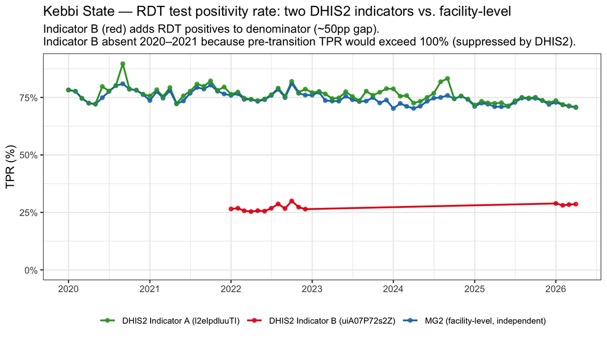

```r
mg2_line   <- mg2_monthly[, .(date, value = mg2_tpr,   source = "MG2 (facility-level, independent)")]
corr_line  <- dhis2_correct[, .(date, value,           source = "DHIS2 Indicator A (l2eIpdluuTI)")]
err_line   <- dhis2_errored[, .(date, value,           source = "DHIS2 Indicator B (uiA07P72s2Z)")]

all_series <- rbindlist(list(mg2_line, corr_line, err_line))

ggplot(all_series, aes(x = date, y = value, colour = source)) +
  geom_line(linewidth = 0.8) +
  geom_point(size = 1.5, alpha = 0.8) +
  scale_colour_manual(values = c(
    "MG2 (facility-level, independent)" = "#1f78b4",
    "DHIS2 Indicator A (l2eIpdluuTI)"   = "#33a02c",
    "DHIS2 Indicator B (uiA07P72s2Z)"   = "#e31a1c"
  )) +
  scale_y_continuous(labels = function(x) paste0(x, "%"), limits = c(0, NA)) +
  scale_x_date(date_breaks = "1 year", date_labels = "%Y") +
  labs(
    title    = "Kebbi State — RDT test positivity rate: two DHIS2 indicators vs. facility-level",
    subtitle = "Indicator B (red) adds RDT positives to denominator (~50pp gap).\nIndicator B absent 2020–2021 because pre-transition TPR would exceed 100% (suppressed by DHIS2).",
    x = NULL, y = "TPR (%)", colour = NULL
  ) +
  theme_bw() +
  theme(legend.position = "bottom", legend.text = element_text(size = 8))
```

### 3.4 Numerator and denominator decomposition

The divergence in denominator values confirms the formula error:

```r
numden <- merge(
  mg2_monthly[, .(date, mg2_num, mg2_den)],
  dhis2_correct[, .(date, d2c_num = numerator, d2c_den = denominator)],
  by = "date", all = FALSE
)
numden <- merge(
  numden,
  dhis2_errored[, .(date, d2e_num = numerator, d2e_den = denominator)],
  by = "date", all.x = TRUE
)
setorder(numden, date)

numden[!is.na(d2e_den), .(
  date,
  `MG2 num`          = format(mg2_num, big.mark = ","),
  `Ind A num`        = format(d2c_num, big.mark = ","),
  `Ind B num`        = format(d2e_num, big.mark = ","),
  `MG2 den`          = format(mg2_den, big.mark = ","),
  `Ind A den`        = format(d2c_den, big.mark = ","),
  `Ind B den`        = format(d2e_den, big.mark = ","),
  `Ind B den / Ind A den` = round(d2e_den / d2c_den, 2)
)]
```

| date | MG2 num | Ind A num | Ind B num | MG2 den | Ind A den | Ind B den | Ind B den / Ind A den |
| --- | --- | --- | --- | --- | --- | --- | --- |
| 2022-01-01 | 61,066 | 61,629 | 37,703 | 80,447 | 80,654 | 142,283 | 1.76 |
| 2022-02-01 | 60,780 | 61,789 | 37,991 | 79,331 | 79,858 | 141,647 | 1.77 |
| 2022-03-01 | 56,999 | 57,881 | 34,829 | 76,858 | 77,465 | 135,346 | 1.75 |
| 2022-04-01 | 54,489 | 54,515 | 32,460 | 73,484 | 73,484 | 127,999 | 1.74 |
| 2022-05-01 | 53,193 | 53,785 | 32,657 | 72,556 | 73,049 | 126,834 | 1.74 |
| 2022-06-01 | 58,888 | 59,451 | 35,624 | 79,524 | 79,970 | 139,421 | 1.74 |
| 2022-07-01 | 69,238 | 69,643 | 43,172 | 91,243 | 91,452 | 161,095 | 1.76 |
| 2022-08-01 | 96,151 | 98,277 | 63,846 | 122,449 | 124,321 | 222,598 | 1.79 |
| 2022-09-01 | 97,556 | 98,776 | 61,261 | 130,159 | 130,717 | 229,493 | 1.76 |
| 2022-10-01 | 89,883 | 93,031 | 61,918 | 110,913 | 113,474 | 206,505 | 1.82 |

[output cut: 6 more lines]

### 3.5 Why MG2 counts differ from DHIS2 Indicator A

The raw facility-level sums (before validity filtering) match DHIS2 Indicator A (`l2eIpdluuTI`) exactly every month. All differences between the MG2 TPR series and Indicator A come from MG2’s **facility-level validity rules**, which DHIS2’s pre-computed indicator does not apply.

```r
total_fm    <- nrow(fac)
missing_den <- fac[is.na(denominator) | denominator == 0, .N]
num_gt_den  <- fac[!is.na(numerator) & !is.na(denominator) &
                     denominator > 0 & numerator > denominator, .N]
missing_num <- fac[is.na(numerator) & !is.na(denominator) & denominator > 0, .N]

cat("=== Facility-month validity breakdown ===\n")
```

```
#> === Facility-month validity breakdown ===
```

```r
cat(sprintf("Total facility-months:                %6d\n", total_fm))
```

```
#> Total facility-months:                 49081
```

```r
cat(sprintf("Missing/zero denominator (excluded):  %6d  (%4.1f%%)\n",
            missing_den,  missing_den  / total_fm * 100))
```

```
#> Missing/zero denominator (excluded):     632  ( 1.3%)
```

```r
cat(sprintf("Numerator > denominator (excluded):   %6d  (%4.1f%%)\n",
            num_gt_den,   num_gt_den   / total_fm * 100))
```

```
#> Numerator > denominator (excluded):      522  ( 1.1%)
```

```r
cat(sprintf("Missing numerator, valid den (→ 0):   %6d  (%4.1f%%)\n",
            missing_num,  missing_num  / total_fm * 100))
```

```
#> Missing numerator, valid den (→ 0):      188  ( 0.4%)
```

```r
monthly_raw  <- fac[, .(raw_num  = sum(numerator, na.rm = TRUE),
                        raw_den  = sum(denominator, na.rm = TRUE)), by = Month]
monthly_filt <- fac[valid == TRUE, .(filt_num = sum(num_adj),
                                     filt_den = sum(denominator)), by = Month]

monthly_raw[,  date := as.Date(Month)]
monthly_filt[, date := as.Date(Month)]

diff_tbl <- merge(monthly_raw[, .(date, raw_num, raw_den)],
                  monthly_filt[, .(date, filt_num, filt_den)],
                  by = "date")
diff_tbl <- merge(diff_tbl,
                  dhis2_correct[, .(date, d2_num = numerator, d2_den = denominator)],
                  by = "date")
diff_tbl[, `:=`(num_diff = raw_num - filt_num, den_diff = raw_den - filt_den)]

cat("=== Raw sums match DHIS2 Indicator A exactly? ===\n")
```

```
#> === Raw sums match DHIS2 Indicator A exactly? ===
```

```r
cat("Months where raw_num != d2_num:", diff_tbl[raw_num != d2_num, .N], "\n")
```

```
#> Months where raw_num != d2_num: 0
```

```r
cat("Months where raw_den != d2_den:", diff_tbl[raw_den != d2_den, .N], "\n\n")
```

```
#> Months where raw_den != d2_den: 0
```

```r
cat("=== Months where MG2 filtered != raw (differs from DHIS2) ===\n")
```

```
#> === Months where MG2 filtered != raw (differs from DHIS2) ===
```

```r
diff_tbl[num_diff != 0 | den_diff != 0,
         .(date,
           `DHIS2 A (=raw) num` = format(d2_num,   big.mark = ","),
           `MG2 filt num`       = format(filt_num,  big.mark = ","),
           `num removed`        = format(num_diff,  big.mark = ","),
           `DHIS2 A (=raw) den` = format(d2_den,   big.mark = ","),
           `MG2 filt den`       = format(filt_den,  big.mark = ","),
           `den removed`        = format(den_diff,  big.mark = ","))]
```

| date | DHIS2 A (=raw) num | MG2 filt num | num removed | DHIS2 A (=raw) den | MG2 filt den | den removed |
| --- | --- | --- | --- | --- | --- | --- |
| 2020-03-01 | 49,704 | 49,605 | 99 | 66,536 | 66,503 | 33 |
| 2020-05-01 | 32,665 | 32,487 | 178 | 45,253 | 45,088 | 165 |
| 2020-06-01 | 42,356 | 39,695 | 2,661 | 53,101 | 52,993 | 108 |
| 2020-07-01 | 42,504 | 42,384 | 120 | 54,636 | 54,601 | 35 |
| 2020-08-01 | 55,870 | 55,810 | 60 | 69,681 | 69,653 | 28 |
| 2020-09-01 | 64,251 | 57,909 | 6,342 | 71,642 | 71,528 | 114 |
| 2020-10-01 | 69,799 | 69,747 | 52 | 88,725 | 88,725 | 0 |
| 2020-11-01 | 55,563 | 55,542 | 21 | 71,069 | 71,069 | 0 |
| 2020-12-01 | 53,475 | 53,338 | 137 | 69,959 | 69,926 | 33 |
| 2021-01-01 | 50,696 | 49,100 | 1,596 | 67,014 | 66,636 | 378 |

[output cut: 61 more lines]

The raw facility sums equal DHIS2 Indicator A to the digit. Every difference comes from three validity rules applied at facility level:

1. **Numerator > denominator — primary driver.** Facility-months where recorded positives exceed tested count are dropped. Because the numerator was inflated *above* the denominator, removing them reduces the numerator more than the denominator.
2. **Missing/zero denominator.** Facility-months with no tested count are excluded entirely. DHIS2 sums the numerator for those rows regardless.
3. **Missing numerator → 0 (minor, offsetting).** When a facility has a valid tested count but no positives recorded, MG2 imputes zero. The effect (0.4% of facility-months) is smaller than the exclusions above.

The magnitude of removed counts has grown in recent years (2024–2025: up to ~9,000 positives removed in a single month), suggesting a deteriorating data quality signal worth monitoring independently of the TPR calculation itself.

## 4 Programme context: who uses which indicator?

Nigeria’s NHMIS/DHIS2 is the official source of malaria surveillance data for the National Malaria Elimination Programme (NMEP), the US President’s Malaria Initiative (PMI), and all major implementing partners. Test positivity rate is a core programme monitoring metric.

Key users who cite Nigeria DHIS2 TPR:

| Organisation | Programme | States / scope | Source |
| --- | --- | --- | --- |
| NMEP / Federal Ministry of Health | National Malaria Strategic Plan 2021–2025 | National | [NMEP 2021](https://mesamalaria.org/wp-content/uploads/2024/07/NATIONAL-MALARIA-STRATEGIC-PLAN-Nigeria-2021-2025-Final.pdf) |
| USAID / PMI | Nigeria Malaria Operational Plan FY 2023 | 11 focus states incl. Kebbi | [USAID 2023](https://files.givewell.org/files/DWDA%202009/Malaria%20Consortium/US_Presidents_Malaria_Initiative_Nigeria_Malaria_Operational_Plan_FY_2023.pdf) |
| MSH / PMI for States (PMI-S) | HMIS quality improvement, Kebbi ~80%, Zamfara 62–89% | Kebbi, Zamfara, Ebonyi | [Data for Impact 2023](https://www.data4impactproject.org/wp-content/uploads/2023/01/Nigeria-DHIS2-Results-Brief_FS-23-611-D4I_508c.pdf) |
| Malaria Consortium | Seasonal malaria chemoprevention (SMC) monitoring | Kebbi, Sokoto, Bauchi | [GiveWell 2023](https://www.givewell.org/research/grants/Malaria-Consortium-SMC-renewal-Nigeria-Burkina-Chad-Togo-January-2023) |

**No programme report or operational plan names the specific DHIS2 indicator UID or formula.** All sources describe TPR generically as “positive tests / total tests performed among febrile patients.” Indicator B (`uiA07P72s2Z`) carries exactly the “TPR” acronym that programme staff and dashboard users would search for; Indicator A uses different terminology.

## 5 Published studies that cite Nigeria DHIS2 TPR without specifying the indicator

A consistent gap in the recent literature on Nigeria malaria is that authors extract test positivity data from DHIS2 without documenting which of the two indicators (or which underlying data elements) was used:

- **Dahunsi et al. (2025)** extracted RDT TPR for Oyo State from DHIS2, 2021–2022 (TPR 70–82%). Defines TPR as “positive tests as a proportion of total tests performed among febrile patients.” No DHIS2 indicator name or UID cited. Funded by PMI; implemented by MSH. *Malaria Journal* 24:65. [PMC12016084](https://pmc.ncbi.nlm.nih.gov/articles/PMC12016084/)
- **Oladoyin et al. (2025)** selected study facilities in Sokoto and Oyo on the basis of “the highest TPR reported on the DHIS2.” Defines TPR as “number of positive tests divided by total tests performed.” No indicator name or UID given. PMI Insights / BMGF-funded. *Malaria Journal* 24 (2025). [PMC12595662](https://pmc.ncbi.nlm.nih.gov/articles/PMC12595662/)
- **Gnansounou et al. (2025)** extracted “number of positive RDT results and total RDTs administered” from DHIS2 across Benin, Côte d’Ivoire, Nigeria, and Uganda. No indicator name or UID specified for any country. PMI-funded. *Malaria Journal* 24 (2025). [PMC12219610](https://pmc.ncbi.nlm.nih.gov/articles/PMC12219610/)
- **Data for Impact / D4I (2023)** reported Kebbi TPR “relatively stable at around 80%” and Zamfara 62–89% from DHIS2, as part of an HMIS data quality evaluation. No indicator name cited. USAID-funded. *Nigeria DHIS2 Evaluation Baseline Results.* [D4I 2023](https://www.data4impactproject.org/wp-content/uploads/2023/01/Nigeria-DHIS2-Results-Brief_FS-23-611-D4I_508c.pdf)
- **Multi-country concordance study (2025)** used DHIS2 aggregate TPR as a facility selection criterion across Nigeria, Uganda, Benin, and Côte d’Ivoire. Neither defined nor attributed to a specific indicator. [PMC12866365](https://pmc.ncbi.nlm.nih.gov/articles/PMC12866365/)

In all five cases, if Indicator B (`uiA07P72s2Z`) was used (via dashboard selection or an analytics API call referencing its UID), the reported TPR would be deflated by roughly 50 percentage points — and the direction and magnitude of any intervention effect, state comparison, or trend analysis would be affected accordingly.

For the studies selecting facilities based on “high TPR on DHIS2”: if Indicator B was the indicator consulted, facilities with genuinely high positivity would show TPR ~25–30% rather than ~75–80%. The ranking of facilities by positivity is preserved (both indicators use the same underlying counts), but the absolute values reported are systematically wrong.

## 6 Implications for the DHIS2 Reporting Checklist

This case illustrates items in **Domain 1: Data Dictionary** of the DHIS2 Reporting Checklist:

> **1c. Indicator specification:** If a pre-computed DHIS2 indicator is used, report the indicator name *and* UID. Verify the indicator formula against instance metadata (DHIS2 maintenance app or API call to `/api/indicators/{uid}.json`) before reporting.

The following practice would have detected and prevented this error:

```r
# Retrieve and inspect indicator formula from DHIS2 API
# Replace with your base_url / credentials
url <- paste0(base_url, "api/indicators/uiA07P72s2Z.json",
              "?fields=name,numerator,denominator,numeratorDescription,denominatorDescription")
resp <- httr::GET(url, httr::authenticate(username, password))
httr::content(resp)
# → denominator expression reveals #{GEd2F6skCpT} (positives) added to denominator
```

Reporting the UID enables readers to: 1. Retrieve the formula from any copy of the instance metadata. 2. Verify it matches the generic definition stated in the Methods section. 3. Detect discrepancies (as demonstrated here) without access to the live DHIS2 instance.

The secondary error — mixing old and new age-disaggregation schemes in a single indicator — illustrates **Domain 5: Instance Attributes** (documenting form version and category scheme transitions). Nigeria’s NHMIS underwent a form revision that introduced a new three-group age breakdown (`<5yrs`, `≥5yrs excl PW`, `Preg Women`) to replace the two-group scheme (`<5yrs`, `>=5years`). Indicators created against the old scheme are not automatically updated; they continue to reference legacy category option combo UIDs that return no data for facilities that have transitioned to the new form.

### 6.1 Evidence of the NHMIS form transition

The NHMIS 2013 form (dataset UID `lyVV9bPLlVy`) was succeeded by the 2019 version (`O82o1WlMisO`). Both include the two data elements used in these indicators. The 2019 form introduced the `NH19_Malaria Testing` category combination with three age groups, replacing the two-group `Age(Malaria)` scheme. In current DHIS2 metadata, `GEd2F6skCpT` (positives) and `r6WOvUlcQm6` (tested) are assigned `NH19_Malaria Testing`; `Age(Malaria)` now appears only for community form data elements.

An additional scope difference: `GEd2F6skCpT` (positives) also appears in the Community Monthly Summary Form; `r6WOvUlcQm6` (tested) does not. If community health extension worker positives flow into state aggregates without a corresponding tested denominator, Indicator A’s default-aggregation denominator may undercount tested cases from community reporting, deflating TPR further.

### 6.2 What cannot be answered from available metadata

The available evidence reveals the *current* formula and its *empirical* consequences, but several historical questions require additional investigation:

- **When was Indicator B created?** The DHIS2 API exposes `created` and `lastUpdated` timestamps for indicator objects. If Indicator B predates the NH19 transition (≈ 2020), the old-scheme COC UIDs in its numerator may have been valid at the time — the error arising from configuration drift when data element category assignments changed without the indicator formula being updated.
- **Was `Age(Malaria)` ever assigned to `GEd2F6skCpT` or `r6WOvUlcQm6`?** An audit trail of category combination assignments — if the Nigeria DHIS2 instance maintains one — would confirm whether these elements previously used `Age(Malaria)`, explaining Indicator B’s old-scheme COC UIDs. Some DHIS2 versions log metadata changes; others do not.
- **How consistently is the tested denominator recorded?** A facility-level comparison of months with valid numerator vs. valid denominator for `r6WOvUlcQm6` would reveal whether the “tested” field is systematically missing for certain facility types or ownership categories. Systematic gaps would bias any TPR estimate regardless of indicator choice.
- **Do community records contribute to state aggregates?** If `GEd2F6skCpT` values from the Community form are included in state rollups without a corresponding tested count, both indicators understate the true denominator.

### 6.3 Building a transparent TPR with MG2

An alternative to relying on pre-built DHIS2 indicators is to compute the ratio directly from facility-level data element values with an explicit, documented formula. The MG2 R package (`build_combined_dataset()`, `operation = "Ratio"`) provides this capability: users select specific data element × category combinations for numerator and denominator, choose which age-disaggregation scheme applies to their analysis window, apply standard validity rules (missing numerator → 0; numerator > denominator → excluded), and save a fully documented formula alongside the computed dataset.

Section 3 of this report is a worked example. The analysis code specifies every data element name and category included in the numerator and denominator. This is reproducible without access to the live DHIS2 instance, and it documents precisely which age groups are summed and under which data quality rules. None of the five programme reports and published studies cited in Section 5 provided equivalent formula detail. Building TPR from data elements rather than pre-computed indicators makes that documentation an automatic byproduct of the analysis workflow — and makes formula errors like those in Indicator B detectable before results are published or used to guide programme decisions.

## 7 Summary

[output not shown]

*Analysis: MG2 R package facility-level computation + DHIS2 analytics API (Kebbi State OU: `M689V9w3Gs3`). Data: Nigeria national HMIS (DHIS2), January 2020 – April 2026. Nigeria DHIS2 credentials required to reproduce DHIS2 indicator series; cached results embedded.*

*Analysis run: 2026-05-30 10:01:16.844807*